# Assignment3

## Assignment 3

Giang Vu

### Instructions

1. Download the jupyter notebook file (this should have a.ipynb extension) as an HTML file (this will have a .html extension) by clicking the **Files** tab and selecting "download as HTML (.html)";
2. Upload both the jupter notebook file (**Assignment3.ipynb**) and the HTML file (**Assignment3.html**) to Canvas page.
3. The files you upload to the Canvas page should be updated with commands you provide to answer each of the questions below. You can edit this file directly to produce your final solutions.

## Background: The Normal Distribution

Recall from your probability class that a random variable $X$ is normally-distributed with mean $\mu$ and variance $\sigma^2$ (denoted $X \sim N(\mu, \sigma^2)$) if it has a probability density function, or *pdf*, equal to

$$f(x) = \frac{1}{\sqrt{2\pi \sigma^2}} e^{-\frac{(x - \mu)^2}{2\sigma^2}},\quad -\infty < x < \infty.$$

In *Python* we can simulate $N(\mu, \sigma^2)$ random variables using the $\texttt{numpy.random.normal()}$ function. For example,

```python
import numpy as np
import matplotlib.pyplot as plt
np.random.seed(1) # Please don't remove this code!
# seed function is used to save the state of a random function,
# so that it can generate same random numbers on multiple executions of the code
# on the same machine or on different machines (for a specific seed value).
# The seed value is the previous value number generated by the generator.
# For the first time when there is no previous value, it uses current system time.

np.random.normal(loc = 10, scale = 3, size = 5)
```

```
array([14.87303609,  8.16473076,  8.41548474,  6.78109413, 12.59622289])
```

outputs 5 normally-distributed random variables with mean equal to 10 and standard deviation (this is $\sigma$) equal to 3.

## Tasks

### Sample means as sample size increases

1. Generate 100 random draws rom the standard normal distribution and save them in an array named **normal100**. Calculate the mean and standard deviation of **normal100**. In words explain why these values aren't exactly equal to 0 and 1.

```python
# You'll want to type your response here. Your response should look like:
# normal100 =
# Of course, your answer should not be commented out.
np.random.seed(2)
normal100 = np.random.normal(loc = 0, scale = 1, size = 100)
print "Mean of these 100 random draws is %s \n" % normal100.mean()
print "Standard deviation of these 100 random draws is %s \n" % normal100.std()
print "The mean and standard deviation are not exactly 0 and 1 because they are calculated from only a random sample of size 100. The bigger the sample size, the closer we will get to the mean 0 and standard deviation 1."
```

```
Mean of these 100 random draws is -0.10374113388259781

Standard deviation of these 100 random draws is 1.037035810569885

The mean and standard deviation are not exactly 0 and 1 because they are calculated from only a random sample of size 100. The bigger the sample size, the closer we will get to the mean 0 and standard deviation 1.
```

The mean and standard deviation aren't exactly equal to 0 and 1 because they are calculated using from random samples.

1. The function $\texttt{matplotlib.pyplot.hist()}$ is a base *Python* graphing function that plots a histogram of its input. Use $\texttt{matplotlib.pyplot.hist()}$ with your array of standard normal random variables from question 1 to produce a histogram of the standard normal distribution.

   *The Jupyter Notebook has two ways to get help. Place the cursor inside the parenthesis of the function, hold down shift , and press tab, or type a function name with a question mark after it.*

   If coded properly, these plots will be automatically embedded in your output file.

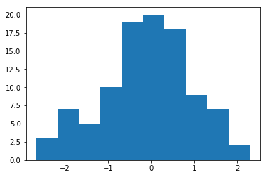

```python
plt.hist(normal100)
```

1. Repeat question 1 except change the number of draws to be 10, 1000, 10,000, and 100,000 and store the results in arrays called **normal10**, **normal1000**, **normal10000**, **normal100000**.

```python
np.random.seed(3)
normal10 = np.random.normal(loc = 0, scale = 1, size = 10)
print "Mean of these 10 random draws is %s \n" % normal10.mean()
print "Standard deviation of these 10 random draws is %s \n" % normal10.std()

np.random.seed(4)
normal1000 = np.random.normal(loc = 0, scale = 1, size = 1000)
print "Mean of these 1000 random draws is %s \n" % normal1000.mean()
print "Standard deviation of these 1000 random draws is %s \n" % normal1000.std()

np.random.seed(5)
normal10000 = np.random.normal(loc = 0, scale = 1, size = 10000)
print "Mean of these 10000 random draws is %s \n" % normal10000.mean()
print "Standard deviation of these 10000 random draws is %s \n" % normal10000.std()

np.random.seed(6)
normal100000 = np.random.normal(loc = 0, scale = 1, size = 100000)
print "Mean of these 100000 random draws is %s \n" % normal100000.mean()
print "Standard deviation of these 100000 random draws is %s \n" % normal100000.std()
```

```
Mean of these 10 random draws is -0.14047824507752982

Standard deviation of these 10 random draws is 0.8664144123449399

Mean of these 1000 random draws is 0.051529617885315716

Standard deviation of these 1000 random draws is 0.9520433940893459

Mean of these 10000 random draws is -0.00029330530299019364

Standard deviation of these 10000 random draws is 1.0008499791458088

Mean of these 100000 random draws is -0.0035527602289197693

Standard deviation of these 100000 random draws is 0.9976261274682505
```

1. We want to compare the means of our four random draws. Create a list called **sample_means** that has as its first element the mean of **normal10**, its second element the mean of **normal100**, its third element the mean of **normal1000**, its fourth element the mean of **normal10000**, and its fifth element the mean of **normal100000**. After you have created the **sample_means** vector, print the contents of the vector and use the $\texttt{len()}$ function to find the length of this list. (it should be five). There are, of course, multiple ways to create this list. Finally, explain in words the pattern we are seeing with the means in the **sample_means** list.

```python
sample_means = [normal10.mean(),normal100.mean(),normal1000.mean(),normal10000.mean(),normal100000.mean()]
print sample_means
print len(sample_means)
print "We can see that as we increase the sample size, the mean gets closer to 0. This is the result of the Law of Large Numbers."
```

```
[-0.14047824507752982, -0.10374113388259781, 0.051529617885315716, -0.00029330530299019364, -0.0035527602289197693]
5
We can see that as we increase the sample size, the mean gets closer to 0. This is the result of the Law of Large Numbers.
```

## Sample distribution of the sample mean

1. Let's push this a little farther. Generate 1 million random draws from a normal distribution with $\mu = 3$ and $\sigma^2 = 4$ and save them in an array named **normal1mil**. Calculate the mean and standard deviation of **normal1mil**.

```python
np.random.seed(7)
normal1mil = np.random.normal(loc = 3, scale = 2, size = 1000000)
print "Mean of these 1 million random draws is %s \n" % normal1mil.mean()
print "Standard deviation of these 1 million random draws is %s \n" % normal1mil.std()
```

```
Mean of these 1 million random draws is 2.9991093040017978

Standard deviation of these 1 million random draws is 2.001696631027195
```

1. Find the mean of all the entries in **normal1mil** that are greater than 3. You may want to generate a new vector first which identifies the elements that fit the criteria.

```python
list1 = []
for num in normal1mil:
    if num > 3:
        list1.append(num)
print "Mean of all the entries in normal1mil that are greater than 3 is %s" % np.array(list1).mean()
```

```
Mean of all the entries in normal1mil that are greater than 3 is 4.595786819818855
```

1. Create an 2D array **normal1mil_mat** from the 1D array **normal1mil** that has 10,000 columns (and therefore should have 100 rows).

```python
normal1mil_mat = normal1mil.reshape(100,10000)
```

[output not shown]

1. Calculate the mean of the $1234^{th}$ column.

```python
print "Mean of the 1234th column is %s" % normal1mil_mat[:,1235].mean()
```

[output not shown]

1. Use the $\texttt{numpy.mean()}$ functions to calculate the *means* of each column of **normal1mil_mat**. Remember, **numpy.mean?** will give you help documents about this function. Save the array of column means with an appropriate name as it will be used in the next task.

```python
normal1mil_cmean = np.mean(normal1mil_mat, axis=0)
print normal1mil_cmean
```

```
[3.23445546 2.92706344 2.81870151 ... 3.21863252 3.24718568 2.74654743]
```

1. Finally, produce a histogram of the column means you calculated in task 9. What is the distribution that this histogram approximates (i.e.\ what is the distribution of the sample mean in this case)?

```
The distribution of the sample mean looks approximately normal with the mean of 3.0
```

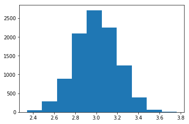

```python
plt.hist(normal1mil_cmean)
print "The distribution of the sample mean looks approximately normal with the mean of 3.0"
```